# 50785 - Analyze capture-mark-recapture data using *mrmr*

Roland Knapp

This notebook analyzes capture-mark-recapture data using the *mrmr* package. The code creates the required survey, capture, and translocation data frames from saved CSV files (created by xxxxx_createdata_mrmr.Rmd), checks the datasets, fits the model, evaluates potential non-convergence of the MCMC algorithm, and visualizes model results.

## Install latest versions of cmdstanr, cmdstan, and mrmr packages

Run only if updated versions were released since previous install

```r
# install cmdstanr and cmdstan
install.packages("cmdstanr", repos = c("https://mc-stan.org/r-packages/", getOption("repos")))
cmdstanr::install_cmdstan()

# install mrmr
remotes::install_github("SNARL1/mrmr")
```

## Load required packages

```r
library(dplyr)
library(readr)
library(tibble)
library(cmdstanr)
library(mrmr)
library(patchwork)
```

## Create required data frames

```r
captures <- read_csv(here::here("data", "clean", "50785_capture.csv"))
surveys <- read_csv(here::here("data", "clean", "50785_survey.csv"))
translocations <- read_csv(here::here("data", "clean", "50785_translocation.csv"))
```

## Check datasets

```r
data_50785 <- clean_data(captures = captures, surveys = surveys, translocations = translocations)
```

## Fit model

Code assumes that there are 8 physical cores available. Update parallel_chains and threads_per_chain as necessary based on actual number of cores. Add “control = list(adapt_delta = 0.99)” or similar if divergent transitions occur.

```r
model_50785 <- fit_model(
                    data = data_50785,
                    chains = 4,
                    parallel_chains = 4,
                    cpp_options = list(stan_threads = TRUE),
                    threads_per_chain = 2)
```

[output not shown]

[output not shown]

[output not shown]

[output not shown]

[output not shown]

[output not shown]

[output not shown]

[output not shown]

[output not shown]

[output cut: 263 more lines]

[output not shown]

[output not shown]

[output not shown]

[output cut: 278 more lines]

[output not shown]

[output not shown]

[output not shown]

[output not shown]

[output not shown]

[output not shown]

[output not shown]

[output not shown]

[output not shown]

[output not shown]

[output not shown]

[output cut: 97 more lines]

[output not shown]

[output not shown]

[output cut: 43 more lines]

```
Chain 4 finished in 134.4 seconds.
Chain 1 Iteration: 1900 / 2000 [ 95%]  (Sampling)
Chain 3 Iteration: 1800 / 2000 [ 90%]  (Sampling)
Chain 2 Iteration: 1900 / 2000 [ 95%]  (Sampling)
Chain 1 Iteration: 2000 / 2000 [100%]  (Sampling)
Chain 1 finished in 144.5 seconds.
Chain 3 Iteration: 1900 / 2000 [ 95%]  (Sampling)
Chain 2 Iteration: 2000 / 2000 [100%]  (Sampling)
Chain 2 finished in 145.9 seconds.
Chain 3 Iteration: 2000 / 2000 [100%]  (Sampling)
Chain 3 finished in 152.6 seconds.

All 4 chains finished successfully.
Mean chain execution time: 144.4 seconds.
Total execution time: 152.7 seconds.
```

- Running model with default adapt_delta (0.8) resulted in zero divergent transition (0/4000).

### Save/retrieve model object

This step prevents having to rerun the model in the event of a crash during model visualizations in subsequent code blocks. Model files can be large, so this saves the file in a compressed format.

```r
write_rds(model_50785, here::here("out", "model", "50785_model.rds"), "xz", compression = 9L)
```

### Diagnose potential non-convergence of the MCMC algorithm

Inspect traceplots and parameter summary table. In table, are any R<sub>hat</sub> values $\ge 1.01$?

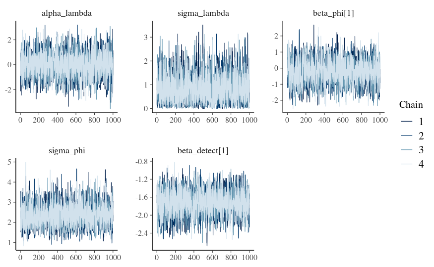

```r
pars_to_plot <- c('alpha_lambda',
                  'sigma_lambda',
                  'beta_phi',
                  'sigma_phi',
                  'beta_detect')
bayesplot::mcmc_trace(model_50785$m_fit$draws(pars_to_plot))
```

```r
model_50785$m_fit$summary(pars_to_plot)
```

| variable | mean | median | sd | mad | q5 | q95 | rhat | ess_bulk | ess_tail |
| --- | --- | --- | --- | --- | --- | --- | --- | --- | --- |
| alpha_lambda | -0.003617579 | -0.01890745 | 0.9556924 | 0.9551332 | -1.57367200 | 1.602482 | 0.999815 | 5881.403 | 3189.829 |
| sigma_lambda | 0.783240777 | 0.66326450 | 0.5961345 | 0.6015805 | 0.05428217 | 1.927859 | 1.000321 | 2778.528 | 1712.366 |
| beta_phi[1] | -0.197958089 | -0.21189100 | 0.7392394 | 0.7313733 | -1.45153150 | 1.030835 | 1.000752 | 2643.974 | 2941.687 |
| sigma_phi | 2.338616940 | 2.28910000 | 0.5462183 | 0.5451891 | 1.52677700 | 3.319225 | 1.000593 | 4120.817 | 3085.920 |
| beta_detect[1] | -1.711566404 | -1.70335000 | 0.2708377 | 0.2621904 | -2.18297450 | -1.278170 | 1.000664 | 3214.357 | 2307.541 |

## Visualize model results

### Default plots

Note: Custom plots (produced in next code chunk: “plots_custom”) are often easier to interpret than the default plots produced by this code chunk.

```r
# plot_model(model_50785, what = "abundance")
# plot_model(model_50785, what = "recruitment")
# plot_model(model_50785, what = "survival")
```

### Customize plots

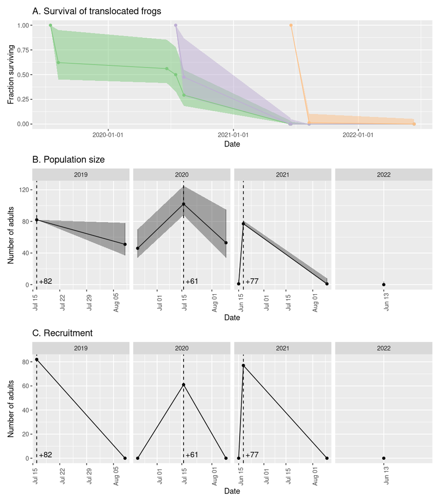

```r
library(ggplot2)
p1 <- plot_model(model_50785, what = "survival")
p1 <- p1 + ggtitle("A. Survival of translocated frogs") +
    expand_limits(y = 0) +
    theme(legend.position = "none")

p2 <- plot_model(model_50785, what = "abundance")
p2 <- p2 + ggtitle("B. Population size") +
    ylab("Number of adults") +
    expand_limits(y = 0)

p3 <- plot_model(model_50785, what = "recruitment")
p3 <- p3 + ggtitle("C. Recruitment") +
    ylab("Number of adults")

p1 / p2 / p3
```

### Save custom plots

```r
ggsave(here::here("out", "plots", "50785_mrmr_plots.png"), width = 6.5, height = 7.2)
```

## Create survival tables

Only the cohort-level survival table is displayed (individual-level survival can be a large table).

```r
survival_cohort <- survival_table(model_50785, by_cohort = TRUE)
survival_cohort
```

| years_since_introduction | release_date | lo_survival | median_survival | hi_survival |
| --- | --- | --- | --- | --- |
| 0 | 2019-07-16 | 0.4512195 | 0.62195122 | 0.95121951 |
| 0 | 2020-07-16 | 0.2786885 | 0.47540984 | 0.86885246 |
| 0 | 2021-06-18 | 0.0000000 | 0.01298701 | 0.10389610 |
| 1 | 2019-07-16 | 0.3252033 | 0.45121951 | 0.69918699 |
| 1 | 2020-07-16 | 0.0000000 | 0.00000000 | 0.03278689 |
| 1 | 2021-06-18 | 0.0000000 | 0.00000000 | 0.05194805 |
| 2 | 2019-07-16 | 0.0000000 | 0.00000000 | 0.02439024 |
| 2 | 2020-07-16 | 0.0000000 | 0.00000000 | 0.00000000 |
| 3 | 2019-07-16 | 0.0000000 | 0.00000000 | 0.00000000 |

### Save survival tables

```r
survival_cohort %>% write_csv(here::here("out", "tables", "50785_survival_cohort.csv"))
survival_ind %>% write_csv(here::here("out", "tables", "50785_survival_ind.csv"))
```